# WDS, HW 3

Aaron

Neil

Ben

Luke

Tanvi

Due: 10:00PM, July 21, 2021

# Case study: Automobiles efficiency

Are cars being built more efficient? Are Asian cars more efficient than cars built in America or Europe? To answer the questions we will use the `Auto` dataset from ISLR. The original dataset contains 408 observations about cars. It is similar to the CARS dataset that we use in our lectures. But it also collects information by years. To get the data, first install the package ISLR. The `Auto` dataset should be loaded automatically. The original data source is here: https://archive.ics.uci.edu/ml/datasets/auto+mpg

Get familiar with this dataset first. A good data set should be well documented. Use the command `?ISLR::Auto` to view a description of the dataset. Please add the variable list with names, brief descriptions and units of the variables below.

# EDA

Explore the data first.

1. What is the range of `year`? Why is this important to know?
   - The range of `year` is 12. This is important because it shows the time span of the dataset.
2. Should `origin` be a continuous variable? Why or why not. In any case make `origin` a categorical variable.
   - By first looking at `origin`, we may think it is a continous variable as it is made up of the numbers 1, 2, and 3. However it is a catagorical varibale and `origin 1, 2, 3` suggest different origins.
3. Do you see any peculiarity in the data?
   - Most of the dataset looks fine, except that the `origin` is named `1, 2, 3`, while we would think they would have distingushed names. This makes it rather peculiar.

## What effect does `time` have on `MPG`?

1. Show a scatter plot of `mpg` vs. `year` with the LS line imposed. Does the plot show a positive trend?
   - Yes, there is a positive trend.

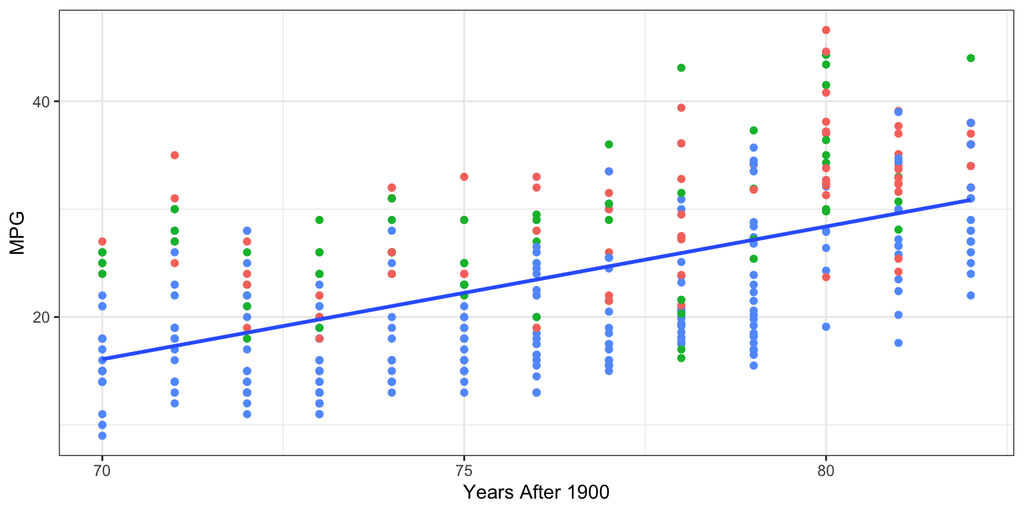

## Bring `origin` into the model

Do `mpg`’s differ on average among different `origin`? Fit a linear model with `mpg` vs. `origin`. Report the output.

```
##
## Call:
## lm(formula = mpg ~ data1$origin, data = data1)
##
## Residuals:
##    Min     1Q Median     3Q    Max
## -12.45  -5.03  -1.03   3.65  18.97
##
## Coefficients:
##               Estimate Std. Error t value Pr(>|t|)
## (Intercept)     30.451      0.720   42.31   <2e-16 ***
## data1$origin2   -2.848      1.058   -2.69   0.0074 **
## data1$origin1  -10.417      0.828  -12.59   <2e-16 ***
## ---
## Signif. codes:  0 '***' 0.001 '**' 0.01 '*' 0.05 '.' 0.1 ' ' 1
##
## Residual standard error: 6.4 on 389 degrees of freedom
## Multiple R-squared:  0.332,  Adjusted R-squared:  0.328
## F-statistic: 96.6 on 2 and 389 DF,  p-value: <2e-16
```

1. Are `mpg`’s on average different among three regions? Perform a test at .01 level. When you reject the null hypothesis, what have you proved?
   - The f statistic produced by `Anova` function is 96.6 which is significantly larger than 1. Since an f statistic of 1 shows the null hypothesis, the very large f statistic shows that we can reject the null hypothesis and say that average of the three `origins` are different in a statistically significant way.

```
## Anova Table (Type II tests)
##
## Response: mpg
##              Sum Sq  Df F value Pr(>F)
## data1$origin   7904   2    96.6 <2e-16 ***
## Residuals     15915 389
## ---
## Signif. codes:  0 '***' 0.001 '**' 0.01 '*' 0.05 '.' 0.1 ' ' 1
```

1. Describe on average which `origin` has the highest `mpg` and what it is. Which `origin` has the smallest `mpg` on average and what is it?
   - On average, `origin 3` has the highest `mpg` of 30.451, and `origin 1` has the lowest average `mpg` of 20.033.